# CSCI E-63C: Week 8 Q&A session

# Questions

- Past problem sets, lectures?
- Week 8 problem set
- Week 8 quiz

# ISLR Ch.10.7, Ex.8

*“In Section 10.2.3, a formula for calculating PVE was given in Equation 10.8. We also saw that the PVE can be obtained using the sdev output of the `prcomp()` function.”*

*“On the `USArrests` data, calculate PVE in two ways:”*

```r
dim(USArrests)
```

```
## [1] 50  4
```

```r
head(USArrests)
```

```
##            Murder Assault UrbanPop Rape
## Alabama      13.2     236       58 21.2
## Alaska       10.0     263       48 44.5
## Arizona       8.1     294       80 31.0
## Arkansas      8.8     190       50 19.5
## California    9.0     276       91 40.6
## Colorado      7.9     204       78 38.7
```

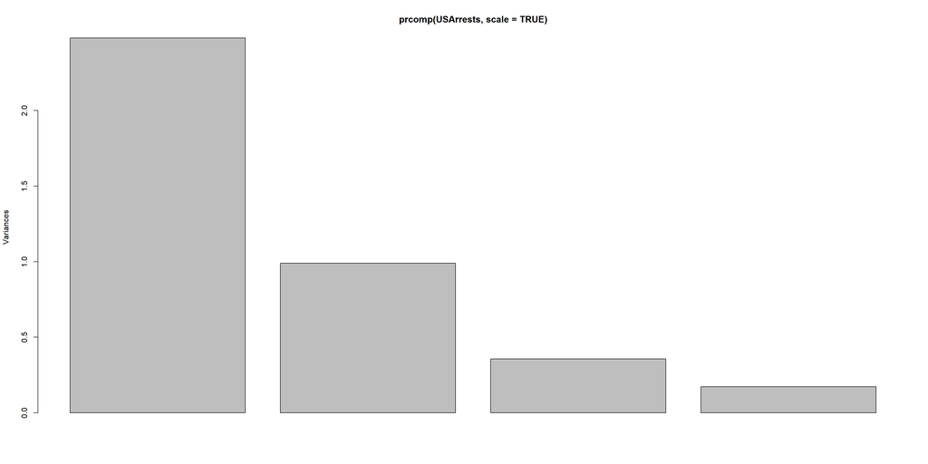

```r
plot(prcomp(USArrests,scale=TRUE))
```

```r
class(prcomp(USArrests,scale=TRUE))
```

```
## [1] "prcomp"
```

```r
mode(prcomp(USArrests,scale=TRUE))
```

```
## [1] "list"
```

```r
pcaRet <- prcomp(USArrests,scale=TRUE)
names(pcaRet)
```

```
## [1] "sdev"     "rotation" "center"   "scale"    "x"
```

*“(a) Using the sdev output of the prcomp() function, as was done in Section 10.2.3.:”*

```r
pcaRet$sdev
```

```
## [1] 1.5748783 0.9948694 0.5971291 0.4164494
```

```r
pcaRet$sdev^2
```

```
## [1] 2.4802416 0.9897652 0.3565632 0.1734301
```

```r
dim(pcaRet$x)
```

```
## [1] 50  4
```

```r
apply(pcaRet$x,2,sd)
```

```
##       PC1       PC2       PC3       PC4
## 1.5748783 0.9948694 0.5971291 0.4164494
```

```r
sum(pcaRet$sdev^2)
```

```
## [1] 4
```

```r
pcaRet$sdev^2/sum(pcaRet$sdev^2)
```

```
## [1] 0.62006039 0.24744129 0.08914080 0.04335752
```

*“By applying Equation 10.8 directly. That is, use the `prcomp()` function to compute the principal component loadings. Then, use those loadings in Equation 10.8 to obtain the PVE.”*

```r
dim(pcaRet$rotation)
```

```
## [1] 4 4
```

```r
sum(colSums(pcaRet$rotation[,1]*t(scale(USArrests)))^2) / sum(scale(USArrests)^2)
```

```
## [1] 0.6200604
```

```r
sum(colSums(pcaRet$rotation[,2]*t(scale(USArrests)))^2) / sum(scale(USArrests)^2)
```

```
## [1] 0.2474413
```

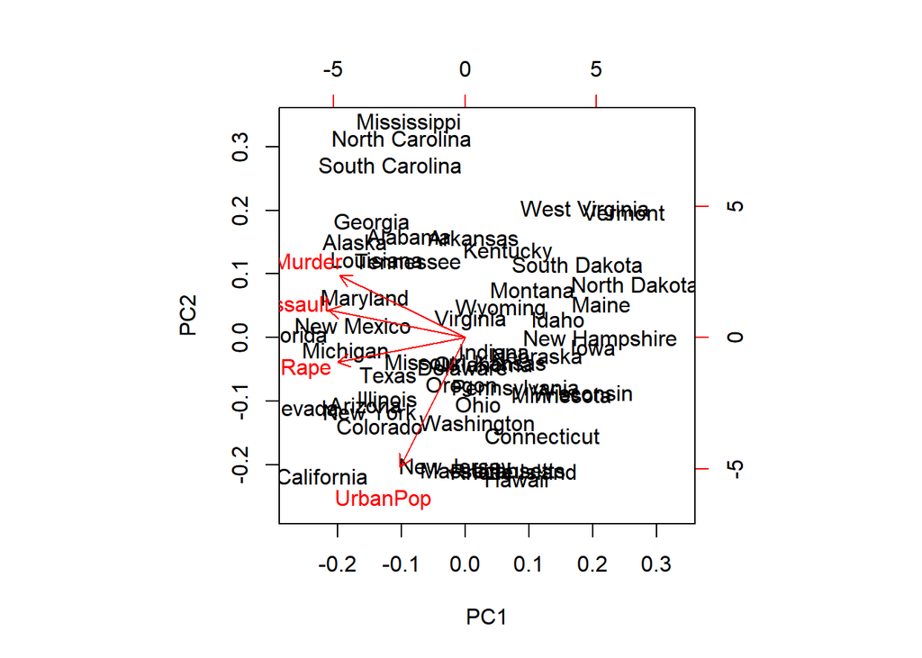

```r
biplot(prcomp(USArrests,scale=TRUE))
```

```r
apply(USArrests,2,sd)
```

```
##    Murder   Assault  UrbanPop      Rape
##  4.355510 83.337661 14.474763  9.366385
```

```r
apply(USArrests,2,var)
```

```
##     Murder    Assault   UrbanPop       Rape
##   18.97047 6945.16571  209.51878   87.72916
```

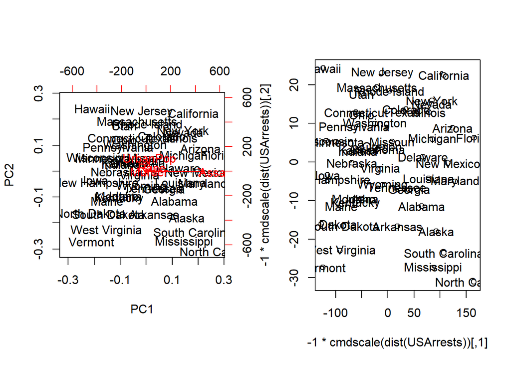

```r
old.par <- par(mfrow=c(1,2))
biplot(prcomp(USArrests))
plot(-1*cmdscale(dist(USArrests)))
text(-1*cmdscale(dist(USArrests)),rownames(cmdscale(dist(USArrests))))
```

```r
par(old.par)
```

# ISLR Ch.10.7, Ex.9

*“Consider the `USArrests` data. We will now perform hierarchical clustering on the states.”*

*“(a) Using hierarchical clustering with complete linkage and Euclidean distance, cluster the states.”*

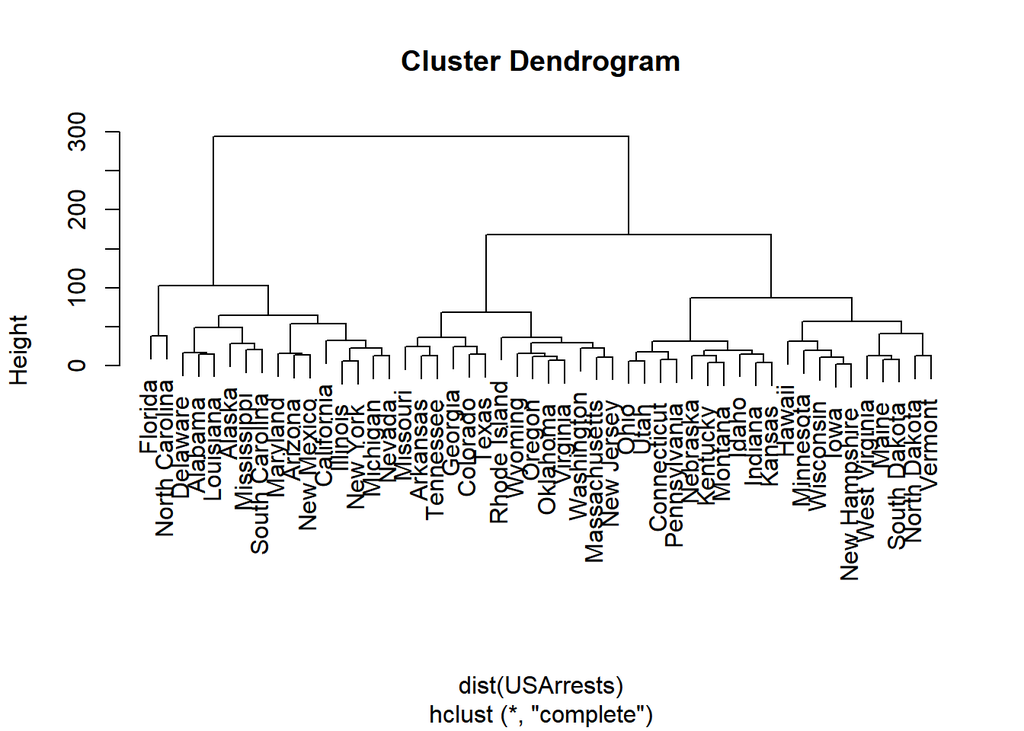

```r
# they are defaults:
#?hclust
plot(hclust(dist(USArrests)))
```

*“(b) Cut the dendrogram at a height that results in three distinct clusters. Which states belong to which clusters?”*

```r
sort(cutree(hclust(dist(USArrests)),k=3))
```

```
##        Alabama         Alaska        Arizona     California       Delaware
##              1              1              1              1              1
##        Florida       Illinois      Louisiana       Maryland       Michigan
##              1              1              1              1              1
##    Mississippi         Nevada     New Mexico       New York North Carolina
##              1              1              1              1              1
## South Carolina       Arkansas       Colorado        Georgia  Massachusetts
##              1              2              2              2              2
##       Missouri     New Jersey       Oklahoma         Oregon   Rhode Island
##              2              2              2              2              2
##      Tennessee          Texas       Virginia     Washington        Wyoming
##              2              2              2              2              2
##    Connecticut         Hawaii          Idaho        Indiana           Iowa
##              3              3              3              3              3
##         Kansas       Kentucky          Maine      Minnesota        Montana
##              3              3              3              3              3
##       Nebraska  New Hampshire   North Dakota           Ohio   Pennsylvania
##              3              3              3              3              3
##   South Dakota           Utah        Vermont  West Virginia      Wisconsin
##              3              3              3              3              3
```

```r
table(cutree(hclust(dist(USArrests)),k=3))
```

```
##
##  1  2  3
## 16 14 20
```

```r
table(cutree(hclust(dist(USArrests)),k=3),cutree(hclust(dist(USArrests)),k=4))
```

```
##
##      1  2  3  4
##   1 14  0  0  2
##   2  0 14  0  0
##   3  0  0 20  0
```

*“(c) Hierarchically cluster the states using complete linkage and Euclidean distance, **after scaling the variables to have standard deviation one.**”*

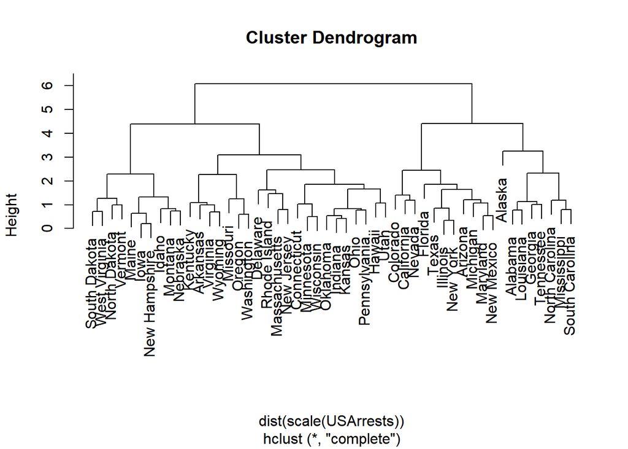

```r
plot(hclust(dist(scale(USArrests))))
```

```r
sort(cutree(hclust(dist(scale(USArrests))),k=3))
```

```
##        Alabama         Alaska        Georgia      Louisiana    Mississippi
##              1              1              1              1              1
## North Carolina South Carolina      Tennessee        Arizona     California
##              1              1              1              2              2
##       Colorado        Florida       Illinois       Maryland       Michigan
##              2              2              2              2              2
##         Nevada     New Mexico       New York          Texas       Arkansas
##              2              2              2              2              3
##    Connecticut       Delaware         Hawaii          Idaho        Indiana
##              3              3              3              3              3
##           Iowa         Kansas       Kentucky          Maine  Massachusetts
##              3              3              3              3              3
##      Minnesota       Missouri        Montana       Nebraska  New Hampshire
##              3              3              3              3              3
##     New Jersey   North Dakota           Ohio       Oklahoma         Oregon
##              3              3              3              3              3
##   Pennsylvania   Rhode Island   South Dakota           Utah        Vermont
##              3              3              3              3              3
##       Virginia     Washington  West Virginia      Wisconsin        Wyoming
##              3              3              3              3              3
```

```r
table(cutree(hclust(dist(scale(USArrests))),k=3))
```

```
##
##  1  2  3
##  8 11 31
```

*“(d) What effect does scaling the variables have on the hierarchical clustering obtained? In your opinion, should the variables be scaled before the inter-observation dissimilarities are computed? Provide a justification for your answer.”*

```r
table(cutree(hclust(dist(USArrests)),k=3),cutree(hclust(dist(scale(USArrests))),k=3))
```

```
##
##      1  2  3
##   1  6  9  1
##   2  2  2 10
##   3  0  0 20
```

# ISLR Ch.10.7, Ex.10

*“In this problem, you will generate simulated data, and then perform PCA and K-means clustering on the data.”*

*“(a) Generate a simulated data set with 20 observations in each of three classes (i.e. 60 observations total), and 50 variables.”*

*“Hint: There are a number of functions in R that you can use to generate data. One example is the `rnorm()` function; `runif()` is another option. Be sure to add a mean shift to the observations in each class so that there are three distinct classes.”*

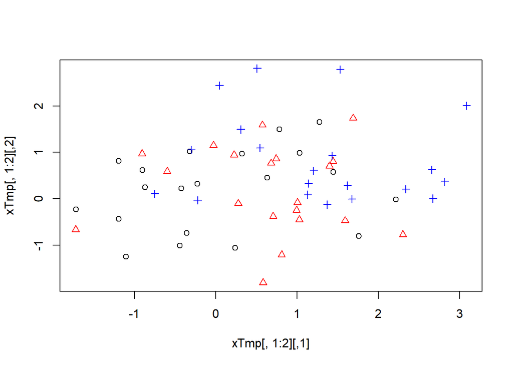

```r
xTmp <- matrix(rnorm(60*50),ncol=50)
cTmp <- c(rep(0,20),rep(0.5,20),rep(1,20))
xTmp <- xTmp + cTmp
plot(xTmp[,1:2],col=c(1,2,4)[as.numeric(factor(cTmp))],pch=as.numeric(factor(cTmp)))
```

*“(b) Perform PCA on the 60 observations and plot the first two principal component score vectors. Use a different color to indicate the observations in each of the three classes. If the three classes appear separated in this plot, then continue on to part (c). If not, then return to part (a) and modify the simulation so that there is greater separation between the three classes. Do not continue to part (c) until the three classes show at least some separation in the first two principal component score vectors.”*

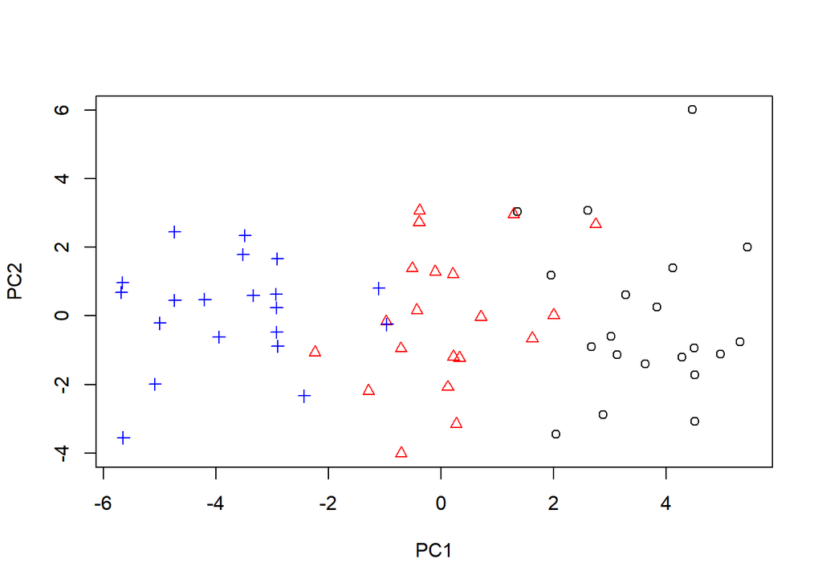

```r
plot(prcomp(xTmp)$x[,1:2],col=c(1,2,4)[as.numeric(factor(cTmp))],pch=as.numeric(factor(cTmp)))
```

*“(c) Perform $K$-means clustering of the observations with $K = 3$. How well do the clusters that you obtained in $K$-means clustering compare to the true class labels?”*

*“Hint: You can use the `table()` function in `R` to compare the true class labels to the class labels obtained by clustering. Be careful how you interpret the results: $K$-means clustering will arbitrarily number the clusters, so you cannot simply check whether the true class labels and clustering labels are the same.”*

```r
kmRes <- kmeans(xTmp,3,nstart=100)
table(kmRes$cluster,cTmp)
```

```
##    cTmp
##      0 0.5  1
##   1 19   2  0
##   2  1  18  3
##   3  0   0 17
```

*“(d) Perform $K$-means clustering with $K = 2$. Describe your results.”*

```r
kmRes <- kmeans(xTmp,2)
table(kmRes$cluster,cTmp)
```

```
##    cTmp
##      0 0.5  1
##   1 20  10  0
##   2  0  10 20
```

*“(e) Now perform K-means clustering with $K = 4$, and describe your results.”*

```r
kmRes <- kmeans(xTmp,4)
table(kmRes$cluster,cTmp)
```

```
##    cTmp
##      0 0.5  1
##   1 11   2  0
##   2  0   0 17
##   3  9   2  0
##   4  0  16  3
```

*“(f) Now perform $K$-means clustering with $K = 3$ on the first two principal component score vectors, rather than on the raw data. That is, perform $K$-means clustering on the $60 \times 2$ matrix of which the first column is the first principal component score vector, and the second column is the second principal component score vector. Comment on the results.”*

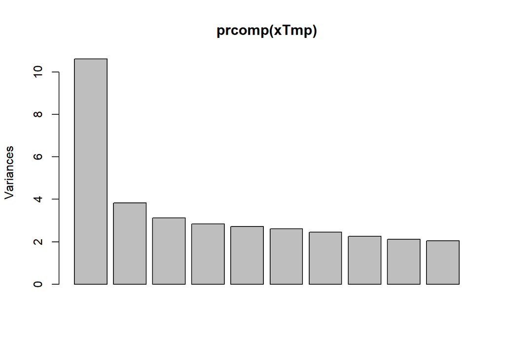

```r
plot(prcomp(xTmp))
```

```r
kmRes <- kmeans(prcomp(xTmp)$x[,1:2],3)
table(kmRes$cluster,cTmp)
```

```
##    cTmp
##      0 0.5  1
##   1  4  16  2
##   2 16   1  0
##   3  0   3 18
```

*“(g) Using the `scale()` function, perform $K$-means clustering with $K = 3$ on the data **after scaling each variable to have standard deviation one.** How do these results compare to those obtained in (b)? Explain.”*

```r
kmRes <- kmeans(scale(xTmp),3)
table(kmRes$cluster,cTmp)
```

```
##    cTmp
##      0 0.5  1
##   1  0  17  3
##   2 20   3  0
##   3  0   0 17
```